# Kaggle Titanic Notes

> *Everything I learned from Kaggle competition **Titanic: ML from Disaster***.

## Theory

##### Workflow stages

1. Preparation
   1. Define the problem.
   2. Acquire training and testing data.
2. Data Manipulation
   1. Overview
   2. Describe the distribution and identify correlation.
   3. Converting data into appropriate types.
   4. Take care of missing values.
   5. Drop unhelpful features.
   6. Create new features.
   7. Visualization.
3. Problem solving

## Analysis

```python
# data analysis and wrangling
import pandas as pd
import numpy as np
import random as rnd

# visualization tool
import seaborn as sns
import matplotlib.pyplot as plt
%matplotlib inline

# acquire training and testing data
train_df = pd.read_csv('../input/train.csv') # local path
test_df = pd.read_csv('../input/test.csv')
combine = [train_df, test_df]
```

### Preparation

###### Define the problem

Knowing from a training set of samples listing passengers who survived or did not survive the Titanic disaster, can our model determine based on a given test dataset not containing the survival information, if these passengers in the test dataset survived or not.

###### Other hints

1. Total survival rate: 32%.
2. Some groups of people were more likely to survive that others, such as women, children, and the upper-class.

###### Notes on code block above

1. `seaborn`: a Python visualization library based on matplotlib.
2. `df = pd.read_csv(<path>)`: reads .csv file into the DataFrame `df`.
3. To access data on Kaggle, use path `"../input/<file>"`.

### Data Manipulation

#### Overview

##### Data Overview

```python
features = train_df.columns.values # return the underlying data as an ndarray

print("Total number of features: ", len(features))
print(features)
```

```
Total number of features:  12
['PassengerId' 'Survived' 'Pclass' 'Name' 'Sex' 'Age' 'SibSp' 'Parch'
 'Ticket' 'Fare' 'Cabin' 'Embarked']
```

```python
train_df.head() # display the first five data points
```

|  | PassengerId | Survived | Pclass | Name | Sex | Age | SibSp | Parch | Ticket | Fare | Cabin | Embarked |
| --- | --- | --- | --- | --- | --- | --- | --- | --- | --- | --- | --- | --- |
| 0 | 1 | 0 | 3 | Braund, Mr. Owen Harris | male | 22.0 | 1 | 0 | A/5 21171 | 7.2500 | NaN | S |
| 1 | 2 | 1 | 1 | Cumings, Mrs. John Bradley (Florence Briggs Th... | female | 38.0 | 1 | 0 | PC 17599 | 71.2833 | C85 | C |
| 2 | 3 | 1 | 3 | Heikkinen, Miss. Laina | female | 26.0 | 0 | 0 | STON/O2. 3101282 | 7.9250 | NaN | S |
| 3 | 4 | 1 | 1 | Futrelle, Mrs. Jacques Heath (Lily May Peel) | female | 35.0 | 1 | 0 | 113803 | 53.1000 | C123 | S |
| 4 | 5 | 0 | 3 | Allen, Mr. William Henry | male | 35.0 | 0 | 0 | 373450 | 8.0500 | NaN | S |

##### Analyze variables

| Variable | Definition | Type | Datatype | Key |
| --- | --- | --- | --- | --- |
| Survived | survival | categorical | integer | 0 = No, 1 = Yes |
| Pclass | ticket class | ordinal | integer | 1 = 1st, 2 = 2nd, 3 = 3rd |
| Sex | Sex | categorical | string | either male or female |
| Age | Age in years | numerical, continuous | floats | has missing values |
| SibSp | # of siblings/spouses | numerical, discrete | integer |  |
| Parch | # of parents/children | numerical, discrete | integer |  |
| Ticket | Ticket number |  | string: numeric+alphanumeric |  |
| Fare | Passenger fare | numerical, continuous | floats |  |
| Cabin | Cabin number |  | string: alphanumeric |  |
| Embarked | Port of Embarkation | categorical | string | C, Q, S stands for ports |

##### Identify possible errors

- *Mixed data types*
  - `Ticket`: a mix of numeric and alphanumeric
  - `Cabin`: alphanumeric
- *Errors and typos*
  - `Name`
- *Blank, null, empty:*

```python
# Identify missing values

total_data_pts = train_df.shape[0]
print("Total data points in the training set: ", total_data_pts)
print('-'*40)
train_df.info() # display general info of the dataset
print('-'*40)
test_df.info()
```

```
Total data points in the training set:  891
----------------------------------------
<class 'pandas.core.frame.DataFrame'>
RangeIndex: 891 entries, 0 to 890
Data columns (total 12 columns):
PassengerId    891 non-null int64
Survived       891 non-null int64
Pclass         891 non-null int64
Name           891 non-null object
Sex            891 non-null object
Age            714 non-null float64
SibSp          891 non-null int64
Parch          891 non-null int64
Ticket         891 non-null object
Fare           891 non-null float64
Cabin          204 non-null object
Embarked       889 non-null object
dtypes: float64(2), int64(5), object(5)
memory usage: 83.6+ KB
----------------------------------------
<class 'pandas.core.frame.DataFrame'>
RangeIndex: 418 entries, 0 to 417
Data columns (total 11 columns):
PassengerId    418 non-null int64
Pclass         418 non-null int64
Name           418 non-null object
Sex            418 non-null object
Age            332 non-null float64
SibSp          418 non-null int64
Parch          418 non-null int64
Ticket         418 non-null object
Fare           417 non-null float64
Cabin          91 non-null object
Embarked       418 non-null object
dtypes: float64(2), int64(4), object(5)
memory usage: 36.0+ KB
```

###### Notes

1. `df.shape` returns a tuple representing the dimensionality of the DataFrame, i.e. *(num_rows, num_cols)*
2. `df.count()` returns a series with number of non-NA/null observations over requested axis.
   - `axis`: `0` for row-wise or `1` for column-wise, default `0`.
3. `df.info()` returns a concise summary of a DataFrame.

We observe that the columns `Cabin`, `Age` and `Embarked` from the training set and the columns `Cabin`, `Age` and `Fare` from the test set are incomplete.

`int64` and `float64` indicate the column is of numerical type; `object` indicates the column is of string type and should be converted to numerical type later.

#### Describe the distribution and identify correlations

##### Describe the distribution

```python
# describe the entire dataframe
train_df.describe()
```

|  | PassengerId | Survived | Pclass | Age | SibSp | Parch | Fare |
| --- | --- | --- | --- | --- | --- | --- | --- |
| count | 891.000000 | 891.000000 | 891.000000 | 714.000000 | 891.000000 | 891.000000 | 891.000000 |
| mean | 446.000000 | 0.383838 | 2.308642 | 29.699118 | 0.523008 | 0.381594 | 32.204208 |
| std | 257.353842 | 0.486592 | 0.836071 | 14.526497 | 1.102743 | 0.806057 | 49.693429 |
| min | 1.000000 | 0.000000 | 1.000000 | 0.420000 | 0.000000 | 0.000000 | 0.000000 |
| 25% | 223.500000 | 0.000000 | 2.000000 | 20.125000 | 0.000000 | 0.000000 | 7.910400 |
| 50% | 446.000000 | 0.000000 | 3.000000 | 28.000000 | 0.000000 | 0.000000 | 14.454200 |
| 75% | 668.500000 | 1.000000 | 3.000000 | 38.000000 | 1.000000 | 0.000000 | 31.000000 |
| max | 891.000000 | 1.000000 | 3.000000 | 80.000000 | 8.000000 | 6.000000 | 512.329200 |

```python
# passing extra parameter `include`
# include = np.object: only show object (string) columns
train_df.describe(include=[np.object])
```

|  | Name | Sex | Ticket | Cabin | Embarked |
| --- | --- | --- | --- | --- | --- |
| count | 891 | 891 | 891 | 204 | 889 |
| unique | 891 | 2 | 681 | 147 | 3 |
| top | Hansen, Mr. Claus Peter | male | CA. 2343 | B96 B98 | S |
| freq | 1 | 577 | 7 | 4 | 644 |

```python
# include = <lst-of-types>: only the columns of the given types
train_df.describe(include=[float, int])
```

|  | PassengerId | Survived | Pclass | Age | SibSp | Parch | Fare |
| --- | --- | --- | --- | --- | --- | --- | --- |
| count | 891.000000 | 891.000000 | 891.000000 | 714.000000 | 891.000000 | 891.000000 | 891.000000 |
| mean | 446.000000 | 0.383838 | 2.308642 | 29.699118 | 0.523008 | 0.381594 | 32.204208 |
| std | 257.353842 | 0.486592 | 0.836071 | 14.526497 | 1.102743 | 0.806057 | 49.693429 |
| min | 1.000000 | 0.000000 | 1.000000 | 0.420000 | 0.000000 | 0.000000 | 0.000000 |
| 25% | 223.500000 | 0.000000 | 2.000000 | 20.125000 | 0.000000 | 0.000000 | 7.910400 |
| 50% | 446.000000 | 0.000000 | 3.000000 | 28.000000 | 0.000000 | 0.000000 | 14.454200 |
| 75% | 668.500000 | 1.000000 | 3.000000 | 38.000000 | 1.000000 | 0.000000 | 31.000000 |
| max | 891.000000 | 1.000000 | 3.000000 | 80.000000 | 8.000000 | 6.000000 | 512.329200 |

```python
# describe a given column
# we can see the value of given percentiles
train_df['Age'].describe(percentiles=[.1, .2, .3, .4, .5, .6, .7, .8, .9, .99])
```

```
count    714.000000
mean      29.699118
std       14.526497
min        0.420000
10%       14.000000
20%       19.000000
30%       22.000000
40%       25.000000
50%       28.000000
60%       31.800000
70%       36.000000
80%       41.000000
90%       50.000000
99%       65.870000
max       80.000000
Name: Age, dtype: float64
```

##### Identify correlation

We pivot features against each other. Note that we can only do this with features that do not have missing values. It also makes sense doing so only for features which are categorical, ordinal, or discrete.

```python
# step-by-step

# suppose we are trying to identify the correlation between Pclass and Survived

data_of_interest = train_df[['Pclass', 'Survived']]

# print(data_of_interest, type(data_of_interest)) # to see the dataframe directly

# group the data points according to Pclass;
# this is why we need the variable to be categorical, ordinal, or discrete
grouped = data_of_interest.groupby(['Pclass'])

# calculate the mean
survival_rate = grouped.mean()

# sort and display
survival_rate.sort_values(by='Survived', ascending=False)

# conclusion: survival rate of first class > second class > third class
```

| Pclass | Survived |
| --- | --- |
| 1 | 0.629630 |
| 2 | 0.472826 |
| 3 | 0.242363 |

###### Notes

- `data_of_interest` object
  - `data_of_interest` is a (891 * 2) DataFrame with `np.narrange(891)` as row labels and [`'Pclass'`, `'Survived'`] as column labels.
  - Each row represents an observation with two attributes: the passenger's Pclass and whether the passenger have survived or not.
- `grouped` object
  - if you do print(type(grouped)), you will see that it is a pandas.core.groupby.DataFrameGroupBy object.

```python
# compact

# extract data of interest
# group by independent variable
# compute the mean (which would generate a new DataFrame)
# sort values by dependent variable

train_df[['Sex', 'Survived']].groupby('Sex').mean().sort_values(by='Survived', ascending=False)

# conclusion: survival rate of women > men
```

| Sex | Survived |
| --- | --- |
| female | 0.742038 |
| male | 0.188908 |

```python
train_df[['SibSp', 'Survived']].groupby('SibSp').mean().sort_values(by='Survived', ascending=False)

# no clear conclusion reached
```

| SibSp | Survived |
| --- | --- |
| 1 | 0.535885 |
| 2 | 0.464286 |
| 0 | 0.345395 |
| 3 | 0.250000 |
| 4 | 0.166667 |
| 5 | 0.000000 |
| 8 | 0.000000 |

```python
train_df[['Parch', 'Survived']].groupby('Parch').mean().sort_values(by='Survived', ascending=False)

# no clear conclusion reached
```

| Parch | Survived |
| --- | --- |
| 3 | 0.600000 |
| 1 | 0.550847 |
| 2 | 0.500000 |
| 0 | 0.343658 |
| 5 | 0.200000 |
| 4 | 0.000000 |
| 6 | 0.000000 |

##### Do some visualization to help us see the patterns

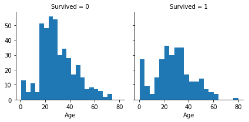

```python
g = sns.FacetGrid(train_df, col='Survived') # y-axis: Survived; being splitted into different subsets
g.map(plt.hist, 'Age', bins=20) # x-axis: Age
```

###### Note for the code block above

- `FacetGrid` is an object that links a Pandas DataFrame to a matplotlib figure with a particular structure.
- In particular, it is used to draw pltos with multiple axes where each axes shows the same relationship conditioned on *different levels of some variable*
- The general approach here to plotting here is called "small multiples", where the same kind of plot is repeated multiple times, and the specific use of small multiples to display the same relationship conditioned on one or more other variables is often called a *trellis plot*.
- *Basic workflow*
  1. Initialize the `FacetGrid` object with the dataset and the variables that are use to structure the grid.
  2. Then one or more plotting functions can be applied to each *subset* by calling `FacetGrid.map()` or `FacetGrid.map_dataframe()`.
  3. Finally, the plot can be tweaked with other methods to do things like change the axis labels, use different ticks, or add a legend.
- *Parameters*
  - `data`: DataFrame; each frame is a variable and each row is an observation
  - `row`, `col`: strings; subsets of data
  - `size`, `aspect`: scalars, size represents height in inches; aspect is the aspect ratio, i.e. `aspect * size` gives the width of each facet in inches.

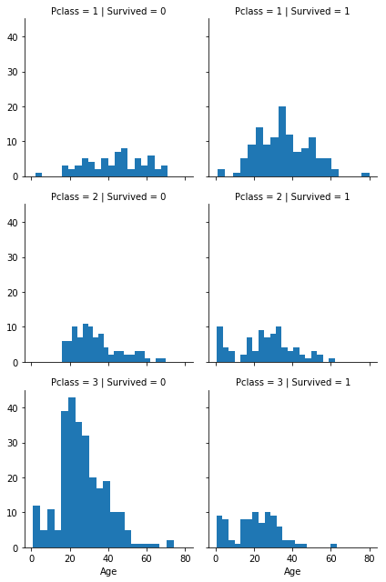

```python
grid = sns.FacetGrid(train_df, col='Survived', row='Pclass') # combine multiple features
grid.map(plt.hist, 'Age', bins=20) # Age is the independent variable
```

###### Note on the code block above

- The `col` and `row` parameters of `FacetGrid` can be think of as the columns and rows of the *entire* (in this case, the set all 6 figures) set of figures. For example, we fed `Pclass` as `row` and `Survived` as `col`; `Survived` has 2 subsets and `Pclass` has 3 subsets, thus we are given a matrix of $3 \times 2$ figures.
- `plt.hist`:
  - *Parameters*: `x` (in the above case, `Age`): array or sequence of arrays.

*We have the following observations:*

1. Third class had most passengers and also lowest survival rate.
2. Many infant passengers from second and third classes surived.
3. Most passengers in the first class survived.
4. `Pclass` varies a bit with `Age` distribution.

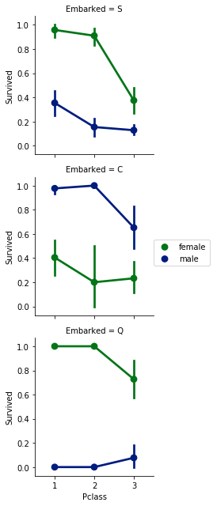

```python
grid = sns.FacetGrid(train_df, row='Embarked')
grid.map(sns.pointplot, 'Pclass', 'Survived', 'Sex', palette='dark')
grid.add_legend()
```

###### Note on the code block above

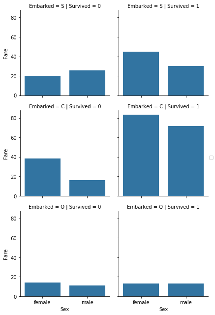

```python
grid = sns.FacetGrid(train_df, row='Embarked', col='Survived')
grid.map(sns.barplot, 'Sex', 'Fare', ci=None)
grid.add_legend()
```

###### Note on the code block above:

- `sns.barplot`: show point estimates and confidence intervals as rectangular bars.
  - A bar plot represents an estimate of central tendency for a numeric variable with the height of each rectangle and provides some indication of the uncertainty around the estimate using error bars.
  - *Parameters*
    - `x`, `y`: inputs for x and y-axis
    - `data`: data for plotting
    - `ci`: size of confidence intervals to draw ardound estimate values.
      - `sd`: draw the standard deviation.
      - `None`: no error bars.

#### Feature Engineering

##### Dropping unhelpful features

Based on our assumptions and decisions, `Cabin` and `Ticket` are not really contributing to the result and we want to drop these two features.

```python
print("Before", train_df.shape, test_df.shape, combine[0].shape, combine[1].shape)

train_df = train_df.drop(['Ticket', 'Cabin'], axis=1)
test_df = test_df.drop(['Ticket', 'Cabin'], axis=1)

combine = [train_df, test_df]

print("After", train_df.shape, test_df.shape, combine[0].shape, combine[1].shape)
```

```
Before (891, 12) (418, 11) (891, 12) (418, 11)
After (891, 10) (418, 9) (891, 10) (418, 9)
```

###### Notes on the code block above

- `df.(['col1', 'col2'], axis=<>)`: return new object with labels in requested axis removed.
  - *Parameters*
    - `labels: single label or list-like index or column labels to drop`
    - `axis`: 0 = 'index', 1 = 'columns', you can use either int or axis name

##### Creating new features from existing ones

We want to extract `Title` from `Name` and see if this affects the survival rate.

```python
for dataset in combine:
    dataset['Title'] = dataset.Name.str.extract('([A-Za-z]+)\.')

pd.crosstab(train_df['Title'], train_df['Sex'])
```

| Sex Title | female | male |
| --- | --- | --- |
| Capt | 0 | 1 |
| Col | 0 | 2 |
| Countess | 1 | 0 |
| Don | 0 | 1 |
| Dr | 1 | 6 |
| Jonkheer | 0 | 1 |
| Lady | 1 | 0 |
| Major | 0 | 2 |
| Master | 0 | 40 |
| Miss | 182 | 0 |
| Mlle | 2 | 0 |
| Mme | 1 | 0 |
| Mr | 0 | 517 |
| Mrs | 125 | 0 |
| Ms | 1 | 0 |
| Rev | 0 | 6 |
| Sir | 0 | 1 |

###### Notes on the code block above

Now we want to replace many titles or a more common name or classify them as `Rare`.

```python
for dataset in combine:
    dataset['Title'] = dataset['Title'].replace(['Lady', 'Countess','Capt', 'Col',\
 	'Don', 'Dr', 'Major', 'Rev', 'Sir', 'Jonkheer', 'Dona'], 'Rare')
    dataset['Title'] = dataset['Title'].replace('Mlle', 'Miss')
    dataset['Title'] = dataset['Title'].replace('Ms', 'Miss')
    dataset['Title'] = dataset['Title'].replace('Mme', 'Mrs')

pd.crosstab(train_df['Title'], train_df['Sex'])
```

| Sex Title | female | male |
| --- | --- | --- |
| Master | 0 | 40 |
| Miss | 185 | 0 |
| Mr | 0 | 517 |
| Mrs | 126 | 0 |
| Rare | 3 | 20 |

Now we examine the correlation between `Title` and `Survived`.

```python
train_df[['Title', 'Survived']].groupby('Title').mean().sort_values(by='Survived', ascending=False)
```

| Title | Survived |
| --- | --- |
| Mrs | 0.793651 |
| Miss | 0.702703 |
| Master | 0.575000 |
| Rare | 0.347826 |
| Mr | 0.156673 |

##### Converting string variables into numerical types

```python
title_mapping = {"Mr": 1, "Miss": 2, "Mrs": 3, "Master": 4, "Rare": 5}

for dataset in combine:
    dataset['Title'] = dataset['Title'].map(title_mapping)
    dataset['Title'] = dataset['Title'].fillna(0)

train_df.head()
```

|  | PassengerId | Survived | Pclass | Name | Sex | Age | SibSp | Parch | Fare | Embarked | Title |
| --- | --- | --- | --- | --- | --- | --- | --- | --- | --- | --- | --- |
| 0 | 1 | 0 | 3 | Braund, Mr. Owen Harris | male | 22.0 | 1 | 0 | 7.2500 | S | 1 |
| 1 | 2 | 1 | 1 | Cumings, Mrs. John Bradley (Florence Briggs Th... | female | 38.0 | 1 | 0 | 71.2833 | C | 3 |
| 2 | 3 | 1 | 3 | Heikkinen, Miss. Laina | female | 26.0 | 0 | 0 | 7.9250 | S | 2 |
| 3 | 4 | 1 | 1 | Futrelle, Mrs. Jacques Heath (Lily May Peel) | female | 35.0 | 1 | 0 | 53.1000 | S | 3 |
| 4 | 5 | 0 | 3 | Allen, Mr. William Henry | male | 35.0 | 0 | 0 | 8.0500 | S | 1 |

###### Notes on the code block above

- `pd.Series.map(self, arg)`: map values of Series using input correspondence.
  - *Parameters*: `arg` can be a function, dict, or Series.
- `pd.Series.fillna(self, value=None, method-None, axis=None)`: fill empty values using the specified method.
  - *Parameters*
    - `value`: scalar, dict, Series, or DataFrame
    - `method`: 'bfill', 'ffill': use last valid/next valid observation to fill the gap.

Now we can safely drop the `Name` feature from training and testing datasets. The `PassengerId` feature is also not helpful.

```python
train_df = train_df.drop(['Name', 'PassengerId'], axis=1)
test_df = test_df.drop(['Name'], axis=1)
combine = [train_df, test_df]
train_df.shape, test_df.shape
```

```
((891, 9), (418, 9))
```

We also need to convert `Sex` into numerical values.

```python
for dataset in combine:
    dataset['Sex'] = dataset['Sex'].map({'female':1, 'male':0}).astype(int)

train_df.head()
```

|  | Survived | Pclass | Sex | Age | SibSp | Parch | Fare | Embarked | Title |
| --- | --- | --- | --- | --- | --- | --- | --- | --- | --- |
| 0 | 0 | 3 | 0 | 22.0 | 1 | 0 | 7.2500 | S | 1 |
| 1 | 1 | 1 | 1 | 38.0 | 1 | 0 | 71.2833 | C | 3 |
| 2 | 1 | 3 | 1 | 26.0 | 0 | 0 | 7.9250 | S | 2 |
| 3 | 1 | 1 | 1 | 35.0 | 1 | 0 | 53.1000 | S | 3 |
| 4 | 0 | 3 | 0 | 35.0 | 0 | 0 | 8.0500 | S | 1 |

##### Deal with missing values

###### Three strategies:

1. Generate a random number in the range $\mu \pm \sigma$.
2. Guessing missing values with help of other correlated features.
3. Combine method 1 and 2: instead of guessing based on median, we use random numbers in the range $\mu \pm \sigma$, based on combinations of correlated features.

###### Age

We noted correlation among `Age`, `Sex`, and `Pclass`.

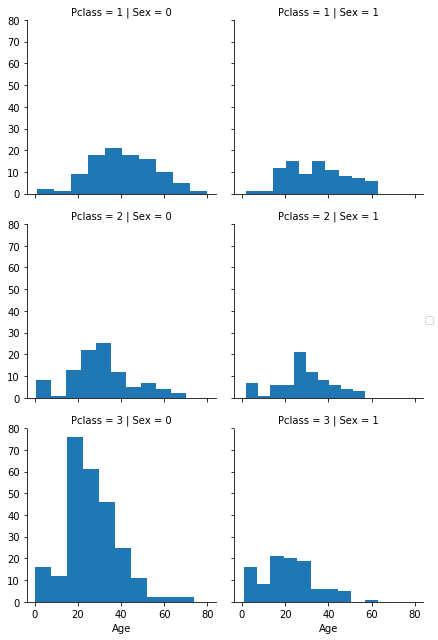

```python
grid = sns.FacetGrid(train_df, row='Pclass', col='Sex')
grid.map(plt.hist, 'Age')
grid.add_legend()
```

Preparing an empty array to contain guessed Age values based on `Pclass * Gender` combinations.

```python
guess_ages = np.zeros((2,3))
guess_ages
```

```
array([[0., 0., 0.],
       [0., 0., 0.]])
```

```python
for dataset in combine:
    for i in range(0, 2):
        for j in range(0, 3):

            # loop over `Sex` and `Pclass` to remove all empty values in column Ages
            # guess_df is a series indexed by arrange(n)
            guess_df = dataset[(dataset['Sex'] == i) & \
                                  (dataset['Pclass'] == j+1)]['Age'].dropna()

            # compute median of guess_df
            age_guess = guess_df.median()

            # we fill the corresponding guess_age
            guess_ages[i,j] = int( age_guess/0.5 + 0.5 ) * 0.5

    # print(guess_ages)

    for i in range(0, 2):
        for j in range(0, 3):

            # we replace missing values in each group by guess_ages[i,j]
            dataset.loc[ (dataset.Age.isnull()) & (dataset.Sex == i) & (dataset.Pclass == j+1),\
                    'Age'] = guess_ages[i,j]

    # convert Age to integer
    dataset['Age'] = dataset['Age'].astype(int)

train_df.head()
```

|  | Survived | Pclass | Sex | Age | SibSp | Parch | Fare | Embarked | Title |
| --- | --- | --- | --- | --- | --- | --- | --- | --- | --- |
| 0 | 0 | 3 | 0 | 22 | 1 | 0 | 7.2500 | S | 1 |
| 1 | 1 | 1 | 1 | 38 | 1 | 0 | 71.2833 | C | 3 |
| 2 | 1 | 3 | 1 | 26 | 0 | 0 | 7.9250 | S | 2 |
| 3 | 1 | 1 | 1 | 35 | 1 | 0 | 53.1000 | S | 3 |
| 4 | 0 | 3 | 0 | 35 | 0 | 0 | 8.0500 | S | 1 |

##### Replacing exact number by range

###### Age Band

```python
# split the entire range into five groups
train_df['AgeBand'] = pd.cut(train_df['Age'], 5)
train_df[['AgeBand', 'Survived']].groupby(['AgeBand'], as_index=False).mean().sort_values(by='AgeBand', ascending=True)
```

|  | AgeBand | Survived |
| --- | --- | --- |
| 0 | (-0.08, 16.0] | 0.550000 |
| 1 | (16.0, 32.0] | 0.337374 |
| 2 | (32.0, 48.0] | 0.412037 |
| 3 | (48.0, 64.0] | 0.434783 |
| 4 | (64.0, 80.0] | 0.090909 |

###### Note on the code block above

- `pd.cut(x, bins)`: return indices of half-open bins to which each values of `x` belongs
  - *Parameters*
    - `x`: array-like, 1D.
    - `bins`: if integer, it represents the number of equal-width bins in the range of `x`.
- `pd.DataFrame.groupby` parameter `as_index`
  - boolean, default `True`.
  - For aggregated output, return object with group labels as the index. This is only relevant for DataFrame intput.

```python
# Now we replace the exact Age by the range index
for dataset in combine:
    dataset.loc[ dataset['Age'] <= 16, 'Age'] = 0
    dataset.loc[(dataset['Age'] > 16) & (dataset['Age'] <= 32), 'Age'] = 1
    dataset.loc[(dataset['Age'] > 32) & (dataset['Age'] <= 48), 'Age'] = 2
    dataset.loc[(dataset['Age'] > 48) & (dataset['Age'] <= 64), 'Age'] = 3
    dataset.loc[ dataset['Age'] > 64, 'Age']
train_df.head()
```

|  | Survived | Pclass | Sex | Age | SibSp | Parch | Fare | Embarked | Title | AgeBand |
| --- | --- | --- | --- | --- | --- | --- | --- | --- | --- | --- |
| 0 | 0 | 3 | 0 | 1 | 1 | 0 | 7.2500 | S | 1 | (16.0, 32.0] |
| 1 | 1 | 1 | 1 | 2 | 1 | 0 | 71.2833 | C | 3 | (32.0, 48.0] |
| 2 | 1 | 3 | 1 | 1 | 0 | 0 | 7.9250 | S | 2 | (16.0, 32.0] |
| 3 | 1 | 1 | 1 | 2 | 1 | 0 | 53.1000 | S | 3 | (32.0, 48.0] |
| 4 | 0 | 3 | 0 | 2 | 0 | 0 | 8.0500 | S | 1 | (32.0, 48.0] |

```python
train_df = train_df.drop(['AgeBand'], axis=1)
combine = [train_df, test_df]
train_df.head()
```

|  | Survived | Pclass | Sex | Age | SibSp | Parch | Fare | Embarked | Title |
| --- | --- | --- | --- | --- | --- | --- | --- | --- | --- |
| 0 | 0 | 3 | 0 | 1 | 1 | 0 | 7.2500 | S | 1 |
| 1 | 1 | 1 | 1 | 2 | 1 | 0 | 71.2833 | C | 3 |
| 2 | 1 | 3 | 1 | 1 | 0 | 0 | 7.9250 | S | 2 |
| 3 | 1 | 1 | 1 | 2 | 1 | 0 | 53.1000 | S | 3 |
| 4 | 0 | 3 | 0 | 2 | 0 | 0 | 8.0500 | S | 1 |

##### Combine and creating new features

```python
# combine `SibSp` and `Parch` to form a new feature: `FamilySize`

for dataset in combine:
    dataset['FamilySize'] = dataset['SibSp'] + dataset['Parch'] + 1

train_df[['FamilySize', 'Survived']
        ].groupby(['FamilySize'], as_index=False).mean().sort_values(by='Survived', ascending=False)
```

|  | FamilySize | Survived |
| --- | --- | --- |
| 3 | 4 | 0.724138 |
| 2 | 3 | 0.578431 |
| 1 | 2 | 0.552795 |
| 6 | 7 | 0.333333 |
| 0 | 1 | 0.303538 |
| 4 | 5 | 0.200000 |
| 5 | 6 | 0.136364 |
| 7 | 8 | 0.000000 |
| 8 | 11 | 0.000000 |

```python
# Create a new feature: `IsAlone`
for dataset in combine:
    dataset['IsAlone'] = 0
    dataset.loc[dataset['FamilySize'] == 1, 'IsAlone'] = 1

train_df[['IsAlone', 'Survived']].groupby(['IsAlone'], as_index=False).mean()
```

|  | IsAlone | Survived |
| --- | --- | --- |
| 0 | 0 | 0.505650 |
| 1 | 1 | 0.303538 |

```python
# we can safely drop these three features
train_df = train_df.drop(['Parch', 'SibSp', 'FamilySize'], axis=1)
test_df = test_df.drop(['Parch', 'SibSp', 'FamilySize'], axis=1)
combine = [train_df, test_df]

train_df.head()
```

|  | Survived | Pclass | Sex | Age | Fare | Embarked | Title | IsAlone |
| --- | --- | --- | --- | --- | --- | --- | --- | --- |
| 0 | 0 | 3 | 0 | 1 | 7.2500 | S | 1 | 0 |
| 1 | 1 | 1 | 1 | 2 | 71.2833 | C | 3 | 0 |
| 2 | 1 | 3 | 1 | 1 | 7.9250 | S | 2 | 1 |
| 3 | 1 | 1 | 1 | 2 | 53.1000 | S | 3 | 0 |
| 4 | 0 | 3 | 0 | 2 | 8.0500 | S | 1 | 1 |

```python
# Replace the missing value in Embarked column by the most frequent one

freq_port = train_df.Embarked.dropna().mode()[0] # mode

for dataset in combine:
    dataset['Embarked'] = dataset['Embarked'].fillna(freq_port) # fill

train_df[['Embarked', 'Survived']].groupby(['Embarked'], as_index=False).mean().sort_values(by='Survived', ascending=False)
```

|  | Embarked | Survived |
| --- | --- | --- |
| 0 | C | 0.553571 |
| 1 | Q | 0.389610 |
| 2 | S | 0.339009 |

```python
# convert categorical variable to numerical value

for dataset in combine:
    dataset['Embarked'] = dataset['Embarked'].map( {'S': 0, 'C': 1, 'Q': 2} ).astype(int)

train_df.head()
```

[output not shown]

```python
# Fill missing values in `Fare` with the median

test_df['Fare'].fillna(test_df['Fare'].dropna().median(), inplace=True)
test_df.head()
```

[output not shown]

```python
# Split range of `Fare` into four groups

train_df['FareBand'] = pd.qcut(train_df['Fare'], 4)
train_df[['FareBand', 'Survived']].groupby(['FareBand'], as_index=False).mean().sort_values(by='FareBand', ascending=True)
```

|  | FareBand | Survived |
| --- | --- | --- |
| 0 | (-0.001, 7.91] | 0.197309 |
| 1 | (7.91, 14.454] | 0.303571 |
| 2 | (14.454, 31.0] | 0.454955 |
| 3 | (31.0, 512.329] | 0.581081 |

```python
# replacing `Fare` by its subgroup range

for dataset in combine:
    dataset.loc[ dataset['Fare'] <= 7.91, 'Fare'] = 0
    dataset.loc[(dataset['Fare'] > 7.91) & (dataset['Fare'] <= 14.454), 'Fare'] = 1
    dataset.loc[(dataset['Fare'] > 14.454) & (dataset['Fare'] <= 31), 'Fare']   = 2
    dataset.loc[ dataset['Fare'] > 31, 'Fare'] = 3
    dataset['Fare'] = dataset['Fare'].astype(int)

train_df = train_df.drop(['FareBand'], axis=1)
combine = [train_df, test_df]

train_df.head(10)
```

[output not shown]

```python
test_df.head(10)
```

[output not shown]

Now we are ready to apply algorithms and make predictions.

Credit: https://www.kaggle.com/startupsci/titanic-data-science-solutions